# Statistical Sampling- Unit 1 - NAEP statistics

Alex Deshowitz

April 30, 2017

The dataframe used in this quick analysis was pulled from the NAEP nation’s report card reports. The data was pulled at the state level for 2009 - 2015. The scores included are Math scores only.

More information regarding the data source can be found here : https://nces.ed.gov/nationsreportcard/

This very high level analysis covers the state of Texas and the changes in the scores for the state over the past 7 years.

```r
packages <- c('plyr', 'sqldf', 'reshape','ggplot2')

sapply(packages, library, character.only = TRUE)
```

[output not shown]

```r
overall_df <- read.csv('Analysis/Data/Math_educ_overall_v01.csv', header = TRUE, skip = 9, nrows = 208)
```

```r
head(overall_df)
```

```
##   Year Jurisdiction Average.scale.score Standard.Error
## 1 2015      Alabama                 267      1.2370776
## 2   NA       Alaska                 280      0.9619621
## 3   NA      Arizona                 283      1.3933827
## 4   NA     Arkansas                 275      1.4291864
## 5   NA   California                 275      1.3250740
## 6   NA     Colorado                 286      1.4710870
```

```r
ncol(overall_df)
```

```
## [1] 4
```

```r
str(overall_df)
```

```
## 'data.frame':    208 obs. of  4 variables:
##  $ Year               : int  2015 NA NA NA NA NA NA NA NA NA ...
##  $ Jurisdiction       : Factor w/ 52 levels "Alabama","Alaska",..: 1 2 3 4 5 6 7 8 9 10 ...
##  $ Average.scale.score: int  267 280 283 275 275 286 284 280 263 291 ...
##  $ Standard.Error     : num  1.237 0.962 1.393 1.429 1.325 ...
```

```r
summary(overall_df)
```

```
##       Year          Jurisdiction Average.scale.score Standard.Error
##  Min.   :2009   Alabama   :  4   Min.   :254         Min.   :0.5051
##  1st Qu.:2010   Alaska    :  4   1st Qu.:278         1st Qu.:0.8355
##  Median :2012   Arizona   :  4   Median :284         Median :1.0131
##  Mean   :2012   Arkansas  :  4   Mean   :283         Mean   :1.0142
##  3rd Qu.:2014   California:  4   3rd Qu.:288         3rd Qu.:1.2044
##  Max.   :2015   Colorado  :  4   Max.   :301         Max.   :1.7877
##  NA's   :204    (Other)   :184
```

The first thing we need to do is create a better year column

```r
years <- unique(overall_df$Year[!is.na(overall_df$Year)])

y <- rep(years, each = 52)

overall_df['new_year'] <- y

# drop the old column

overall_df$Year <- NULL
```

Let’s reorder the dataframe now

```r
overall_df<- overall_df[,c("new_year","Jurisdiction","Average.scale.score","Standard.Error")]

# rename

overall_df <- rename (overall_df, c('new_year' = 'year','Jurisdiction' = 'jurisdiction', 'Average.scale.score' = 'avg_scale_score', 'Standard.Error' = 'std_error'))
```

It looks like the standard error column is still funky; let’s take a look at it

```r
str(overall_df)
```

```
## 'data.frame':    208 obs. of  4 variables:
##  $ year           : int  2015 2015 2015 2015 2015 2015 2015 2015 2015 2015 ...
##  $ jurisdiction   : Factor w/ 52 levels "Alabama","Alaska",..: 1 2 3 4 5 6 7 8 9 10 ...
##  $ avg_scale_score: int  267 280 283 275 275 286 284 280 263 291 ...
##  $ std_error      : num  1.237 0.962 1.393 1.429 1.325 ...
```

It looks like our data is now good to go

How does Texas rank compared to other states in the country

```r
# order the data by score

analysis_df <- overall_df[order(overall_df$year, overall_df$avg_scale_score, decreasing =TRUE), ]


# let'st just look at the 2015 values first:

analysis_df <- subset(analysis_df, year == 2015)

# rank

analysis_df$rank<- NA

analysis_df$rank <- 1:nrow(analysis_df)

head(analysis_df, 53)
```

```
##    year         jurisdiction avg_scale_score std_error rank
## 23 2015        Massachusetts             297 1.4251418    1
## 25 2015            Minnesota             294 1.0234131    2
## 31 2015        New Hampshire             294 0.8990043    3
## 32 2015           New Jersey             293 1.2362303    4
## 10 2015                DoDEA             291 0.7241963    5
## 47 2015              Vermont             290 0.7428193    6
## 51 2015            Wisconsin             289 1.3076917    7
## 36 2015         North Dakota             288 0.6657762    8
## 48 2015             Virginia             288 1.2450256    9
## 16 2015              Indiana             287 1.1779016   10
## 28 2015              Montana             287 0.8479167   11
## 49 2015           Washington             287 1.2823022   12
## 52 2015              Wyoming             287 0.7221022   13
## 6  2015             Colorado             286 1.4710870   14
```

[output cut: 38 more lines]

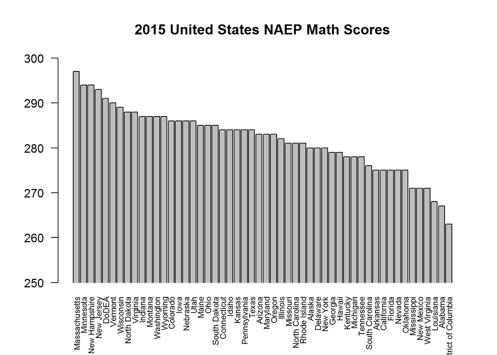

```r
# let's look at the ranks of the math scores

barplot(analysis_df$avg_scale_score, names.arg = analysis_df$jurisdiction, cex.names = 0.7, las = 2, ylim = c(250,300), xpd = FALSE, main = "2015 United States NAEP Math Scores")
```

It looks like Texas is ranked 25 in 2015. I wonder if that has changed over the past several years?

```r
# need to rank and pull the data together for the previous years:

# create subdfs (not the most efficient, but will be easy to rank)

analysis_df_2014 <- subset(overall_df, year == 2014)
analysis_df_2013 <- subset(overall_df, year == 2013)
analysis_df_2012 <- subset(overall_df, year == 2012)
analysis_df_2011 <- subset(overall_df, year == 2011)
analysis_df_2010 <- subset(overall_df, year == 2010)
analysis_df_2009 <- subset(overall_df, year == 2009)

rm(analysis_df_2010, analysis_df_2012, analysis_df_2014)

# now, we need to make sure that the ordering was maintainted

head(analysis_df_2013)
```

```
##    year jurisdiction avg_scale_score std_error
## 53 2013      Alabama             269  1.339240
## 54 2013       Alaska             282  0.934323
## 55 2013      Arizona             280  1.213533
## 56 2013     Arkansas             278  1.076064
## 57 2013   California             276  1.178424
## 58 2013     Colorado             290  1.225326
```

```r
# looks like it wasn't...let's resort all DFs

analysis_df_2013 <- analysis_df_2013[order(analysis_df_2013$year, analysis_df_2013$avg_scale_score, decreasing =TRUE), ]

analysis_df_2011 <- analysis_df_2011[order(analysis_df_2011$year, analysis_df_2011$avg_scale_score, decreasing =TRUE), ]

analysis_df_2009 <- analysis_df_2009[order(analysis_df_2009$year, analysis_df_2009$avg_scale_score, decreasing =TRUE), ]

# looks like reordering worked well.  Now, let's add in the rank column:

analysis_df_2013$rank<- NA
analysis_df_2013$rank <- 1:nrow(analysis_df_2013)


analysis_df_2011$rank<- NA
analysis_df_2011$rank <- 1:nrow(analysis_df_2011)

analysis_df_2009$rank<- NA
analysis_df_2009$rank <- 1:nrow(analysis_df_2009)
```

Now, we should be good to go for a little more analysis. We may want to consolidate all of this information into one dataframe just to be “tidy”

```r
# a very untidy approach, but works...Should really use the merge functionality in the Tidyverse

tidy_df <- sqldf('Select T1.jurisdiction As jurisdiction,
T1.rank As "2015_rank",
T1.avg_scale_score As "2015_avg_score",
T1.std_error As "2015_std_error",

T4.rank As "2013_rank",
T4.avg_scale_score As "2013_avg_score",
T4.std_error As "2013_std_error",

T3.rank As "2011_rank",
T3.avg_scale_score As "2011_avg_score",
T3.std_error As "2011_std_error",

T2.rank As "2009_rank",
T2.avg_scale_score As "2009_avg_score",
T2.std_error As "2009_std_error"


From analysis_df T1

Left Outer Join analysis_df_2009 T2
On T1.jurisdiction = T2.jurisdiction

Left Outer Join analysis_df_2011 T3
On T1.jurisdiction = T3.jurisdiction

Left Outer Join analysis_df_2013 T4
On T1.jurisdiction = T4.jurisdiction')
# remove the unused dfs from the environment

rm(analysis_df_2009, analysis_df_2011, analysis_df_2013)
```

Let’s look at the scores for Texas over the past few years

```r
par(mfrow = c(1,2))

texas_df <- subset(tidy_df, tidy_df$jurisdiction == "Texas")

# proly want to melt it


texas_df <- melt(texas_df)
```

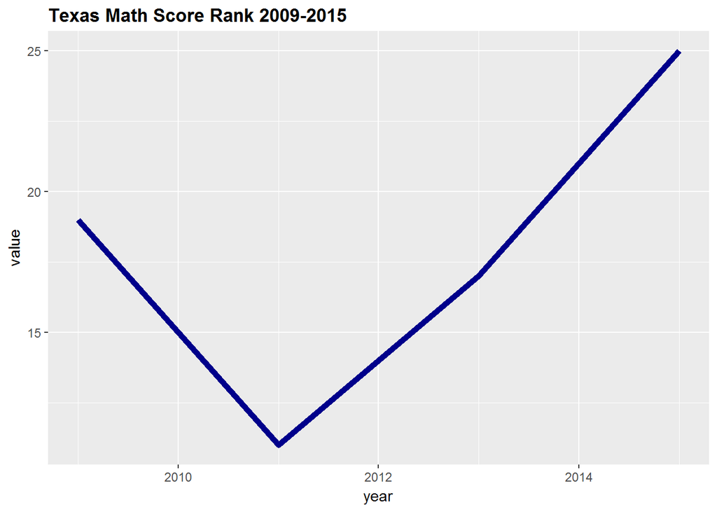

```r
texas_df <- sqldf('Select * From texas_df Where variable Like ("%rank%")')

texas_df$year <- c(2015, 2013, 2011, 2009)

ggplot(data = texas_df, aes(x = year, y = value)) + geom_line(color = 'dark blue', size = 2) + ggtitle('Texas Math Score Rank 2009-2015') + theme(plot.title = element_text(lineheight = 0.8, face = 'bold'))
```

```r
# do the same for score

texas_df <- subset(tidy_df, tidy_df$jurisdiction == "Texas")

texas_df <- melt(texas_df)
```

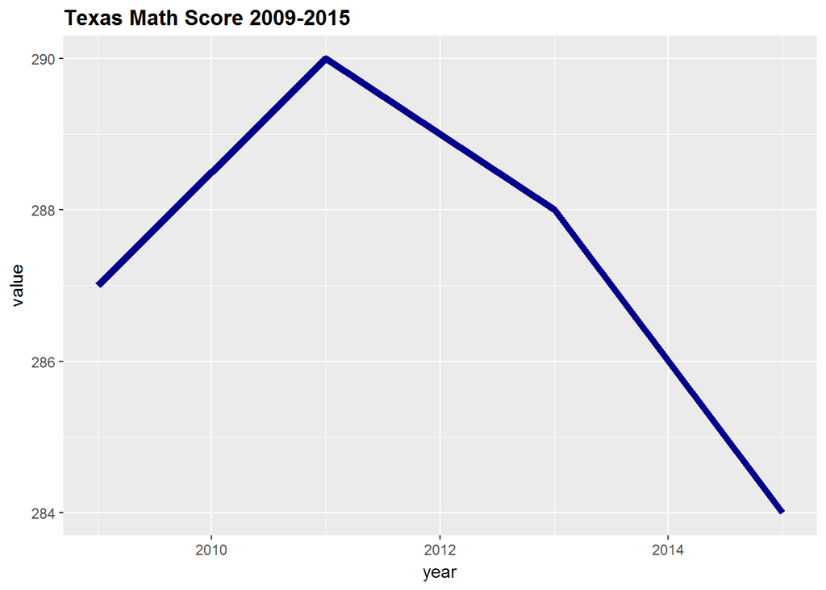

```r
texas_df <- sqldf('Select * From texas_df Where variable Like ("%score%")')

texas_df$year <- c(2015, 2013, 2011, 2009)

ggplot(data = texas_df, aes(x = year, y = value)) + geom_line(color = 'dark blue', size = 2) + ggtitle('Texas Math Score 2009-2015') + theme(plot.title = element_text(lineheight = 0.8, face = 'bold'))
```

Maybe this is a little misleading, but what it shows is that the math score rankings for Texas have dropped over the past 7 years. So, it looks like the real issue is that the Texas Math score has dropped over the past few years. WE would need to look at some additional information to figure out why this is the case. I wonder if the new score is statistically significantly different from 2009 levels though. Remember that ggplot has automatically truncated the axis

```r
# change since 2009

(subset(tidy_df, tidy_df$jurisdiction == "Texas"))$'2015_avg_score'
```

```
## [1] 284
```

```r
(subset(tidy_df, tidy_df$jurisdiction == "Texas"))$'2009_avg_score'
```

```
## [1] 287
```

```r
(subset(tidy_df, tidy_df$jurisdiction == "Texas"))$'2015_avg_score' /
(subset(tidy_df, tidy_df$jurisdiction == "Texas"))$'2009_avg_score' -1
```

```
## [1] -0.01045296
```

```r
# peak score

(subset(tidy_df, tidy_df$jurisdiction == "Texas"))$'2011_avg_score'
```

```
## [1] 290
```

```r
# difference from peak

(subset(tidy_df, tidy_df$jurisdiction == "Texas"))$'2015_avg_score' /
(subset(tidy_df, tidy_df$jurisdiction == "Texas"))$'2011_avg_score' -1
```

```
## [1] -0.02068966
```

The score has only dropped 1% since 2009. Granted, the peak score of 290 has seen a 2% decline. I wonder if the testing procedures changed or something?

Let’s see if the difference between the years has a statistically significant difference.

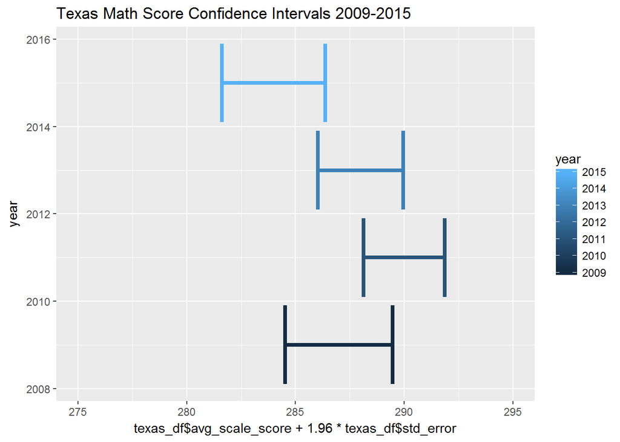

```r
# let's look at error bars for the overlap possibilities usng the overall cleaned frame:

texas_df = subset(overall_df, overall_df$jurisdiction == 'Texas')

# reorder

texas_df = sqldf('Select * From texas_df Order By year')

# now plot the 95% confidence intervals: note that the std. error has already been calculated for us:


ggplot(texas_df, aes(x = year, color = year))+  geom_errorbar(aes(ymax = texas_df$avg_scale_score + 1.96*texas_df$std_error), ymin = texas_df$avg_scale_score - 1.96*texas_df$std_error, position = 'dodge', lwd = 1.5) + coord_flip(ylim = c(295, 275)) + ggtitle('Texas Math Score Confidence Intervals 2009-2015')
```

It looks like the 2011 score is statistically significantly different from the 2015 score. Of course, we are not making any adjustments such as bonferroni for multiple comparisons. It does appear however, that 2015 does show some signs of being significatnly worse for Texas than the other years.